# Evaluación Interactiva de Matemáticas ICFES

El Cristo Redentor en Río de Janeiro es uno de los sitios turísticos más representativos de Brasil. En la tabla se relaciona la cantidad de personas que ingresó cada día durante una semana, según el tipo de entrada que pagó.

Se pagan 120 reales de entrada y 15 más si se realiza reserva.

Cantidad de personas que ingresaron

| Tipo de entrada | Lunes | Martes | Miércoles | Jueves | Viernes | Sábado | Domingo |
| --- | --- | --- | --- | --- | --- | --- | --- |
| Sin reserva | 400 | 300 | 600 | 600 | 400 | 400 | 700 |
| Con reserva | 600 | 600 | 200 | 600 | 600 | 500 | 500 |

El administrador diseñó el siguiente proceso para analizar la recaudación:

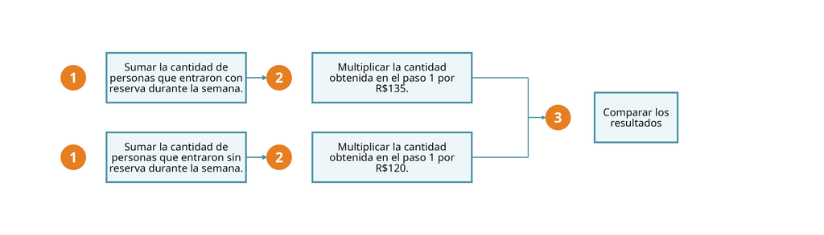

¿Cuál de las siguientes preguntas **NO** se puede resolver únicamente con la información obtenida mediante este proceso?

¿Cuál fue el total de dinero recogido por ambos casos durante la semana?¿En cuál día de la semana se recogió más dinero?¿En cuál de los dos casos se recogió más dinero durante la semana?¿Cuál fue la ganancia total del Cristo Redentor durante la semana?

Para resolver este problema, debemos analizar qué información proporciona el proceso descrito:

**Información que SÍ se puede obtener del proceso:**

1. **Recaudación por tipo de entrada**: El proceso calcula cuánto dinero se recogió de personas con reserva (cantidad × 135 reales) y sin reserva (cantidad × 120 reales).
2. **Comparación entre casos**: El paso 3 permite comparar los resultados, determinando cuál tipo de entrada generó más ingresos.
3. **Total recaudado**: Sumando ambos resultados se obtiene el total de dinero recogido.

**Información que NO se puede obtener:**

- **Ganancia total**: La ganancia requiere conocer los costos operativos del Cristo Redentor (personal, mantenimiento, servicios, etc.), información que no está incluida en el proceso.
- **Día específico**: El proceso trabaja con totales de la semana, no con datos diarios.

Las Cataratas del Iguazú en Misiones es uno de los sitios turísticos más representativos de Argentina. En la tabla se relaciona la cantidad de personas que ingresó cada día durante una semana, según el tipo de entrada que pagó.

Se pagan 40.000 pesos argentinos de entrada y 8.000 más si se realiza reserva.

Cantidad de personas que ingresaron

| Tipo de entrada | Lunes | Martes | Miércoles | Jueves | Viernes | Sábado | Domingo |
| --- | --- | --- | --- | --- | --- | --- | --- |
| Sin reserva | 300 | 300 | 500 | 700 | 400 | 300 | 700 |
| Con reserva | 600 | 800 | 200 | 600 | 500 | 400 | 500 |

El administrador diseñó el siguiente proceso para analizar la recaudación:

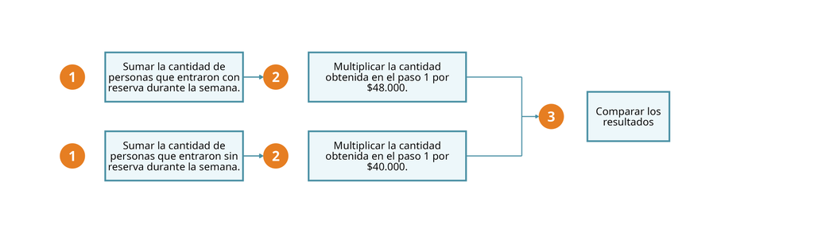

¿Cuál de las siguientes preguntas **NO** se puede resolver únicamente con la información obtenida mediante este proceso?

¿Cuál fue la ganancia total de la Cataratas del Iguazú durante la semana?¿En cuál día de la semana se recogió más dinero?¿Cuál fue el total de dinero recogido por ambos casos durante la semana?¿En cuál de los dos casos se recogió más dinero durante la semana?

Para resolver este problema, debemos analizar qué información proporciona el proceso descrito:

**Información que SÍ se puede obtener del proceso:**

1. **Recaudación por tipo de entrada**: El proceso calcula cuánto dinero se recogió de personas con reserva (cantidad × 48.000 pesos argentinos) y sin reserva (cantidad × 40.000 pesos argentinos).
2. **Comparación entre casos**: El paso 3 permite comparar los resultados, determinando cuál tipo de entrada generó más ingresos.
3. **Total recaudado**: Sumando ambos resultados se obtiene el total de dinero recogido.

**Información que NO se puede obtener:**

- **Ganancia total**: La ganancia requiere conocer los costos operativos de la Cataratas del Iguazú (personal, mantenimiento, servicios, etc.), información que no está incluida en el proceso.
- **Día específico**: El proceso trabaja con totales de la semana, no con datos diarios.

El Salar de Uyuni en Potosí es uno de los sitios turísticos más representativos de Bolivia. En la tabla se relaciona la cantidad de personas que ingresó cada día durante una semana, según el tipo de entrada que pagó.

Se pagan 140 bolivianos de entrada y 25 más si se realiza reserva.

Cantidad de personas que ingresaron

| Tipo de entrada | Lunes | Martes | Miércoles | Jueves | Viernes | Sábado | Domingo |
| --- | --- | --- | --- | --- | --- | --- | --- |
| Sin reserva | 300 | 300 | 500 | 600 | 300 | 300 | 600 |
| Con reserva | 600 | 800 | 200 | 400 | 400 | 500 | 700 |

El administrador diseñó el siguiente proceso para analizar la recaudación:

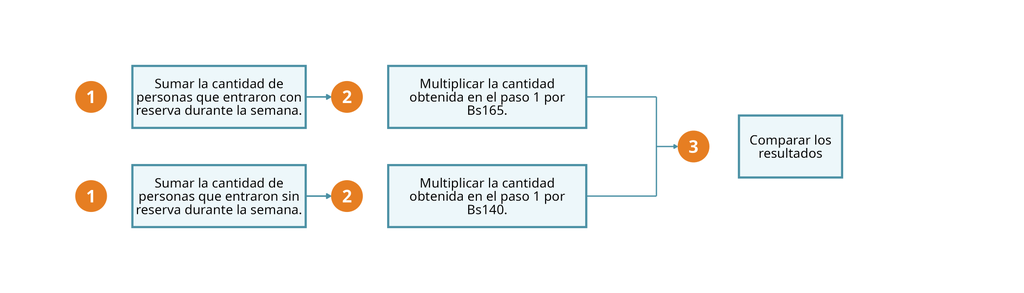

¿Cuál de las siguientes preguntas **NO** se puede resolver únicamente con la información obtenida mediante este proceso?

¿Cuál fue el total de dinero recogido por ambos casos durante la semana?¿Cuál fue la ganancia total del Salar de Uyuni durante la semana?¿En cuál día de la semana se recogió más dinero?¿En cuál de los dos casos se recogió más dinero durante la semana?

Para resolver este problema, debemos analizar qué información proporciona el proceso descrito:

**Información que SÍ se puede obtener del proceso:**

1. **Recaudación por tipo de entrada**: El proceso calcula cuánto dinero se recogió de personas con reserva (cantidad × 165 bolivianos) y sin reserva (cantidad × 140 bolivianos).
2. **Comparación entre casos**: El paso 3 permite comparar los resultados, determinando cuál tipo de entrada generó más ingresos.
3. **Total recaudado**: Sumando ambos resultados se obtiene el total de dinero recogido.

**Información que NO se puede obtener:**

- **Ganancia total**: La ganancia requiere conocer los costos operativos del Salar de Uyuni (personal, mantenimiento, servicios, etc.), información que no está incluida en el proceso.
- **Día específico**: El proceso trabaja con totales de la semana, no con datos diarios.

El Caño Cristales en La Macarena, Meta es uno de los sitios turísticos más representativos de Colombia. En la tabla se relaciona la cantidad de personas que ingresó cada día durante una semana, según el tipo de entrada que pagó.

Se pagan 41.000 pesos de entrada y 10.000 más si se realiza reserva.

Cantidad de personas que ingresaron

| Tipo de entrada | Lunes | Martes | Miércoles | Jueves | Viernes | Sábado | Domingo |
| --- | --- | --- | --- | --- | --- | --- | --- |
| Sin reserva | 300 | 300 | 600 | 700 | 300 | 300 | 500 |
| Con reserva | 800 | 700 | 200 | 500 | 500 | 400 | 700 |

El administrador diseñó el siguiente proceso para analizar la recaudación:

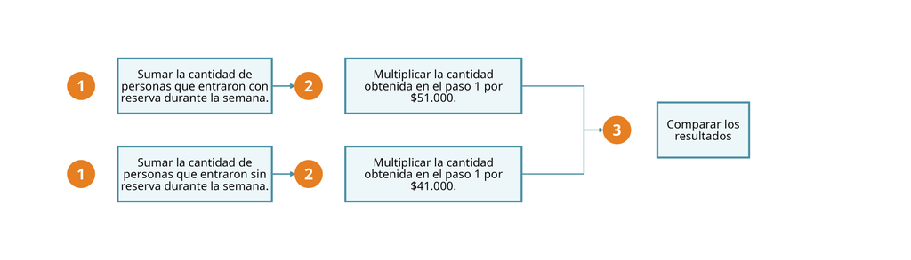

¿Cuál de las siguientes preguntas **NO** se puede resolver únicamente con la información obtenida mediante este proceso?

¿En cuál de los dos casos se recogió más dinero durante la semana?¿En cuál día de la semana se recogió más dinero?¿Cuál fue la ganancia total del Caño Cristales durante la semana?¿Cuál fue el total de dinero recogido por ambos casos durante la semana?

Para resolver este problema, debemos analizar qué información proporciona el proceso descrito:

**Información que SÍ se puede obtener del proceso:**

1. **Recaudación por tipo de entrada**: El proceso calcula cuánto dinero se recogió de personas con reserva (cantidad × 51.000 pesos) y sin reserva (cantidad × 41.000 pesos).
2. **Comparación entre casos**: El paso 3 permite comparar los resultados, determinando cuál tipo de entrada generó más ingresos.
3. **Total recaudado**: Sumando ambos resultados se obtiene el total de dinero recogido.

**Información que NO se puede obtener:**

- **Ganancia total**: La ganancia requiere conocer los costos operativos del Caño Cristales (personal, mantenimiento, servicios, etc.), información que no está incluida en el proceso.
- **Día específico**: El proceso trabaja con totales de la semana, no con datos diarios.

La Catedral de Sal en Zipaquirá, Cundinamarca es uno de los sitios turísticos más representativos de Colombia. En la tabla se relaciona la cantidad de personas que ingresó cada día durante una semana, según el tipo de entrada que pagó.

Se pagan 75.000 pesos de entrada y 12.000 más si se realiza reserva.

Cantidad de personas que ingresaron

| Tipo de entrada | Lunes | Martes | Miércoles | Jueves | Viernes | Sábado | Domingo |
| --- | --- | --- | --- | --- | --- | --- | --- |
| Sin reserva | 300 | 400 | 400 | 700 | 400 | 400 | 700 |
| Con reserva | 500 | 800 | 300 | 700 | 500 | 500 | 600 |

El administrador diseñó el siguiente proceso para analizar la recaudación:

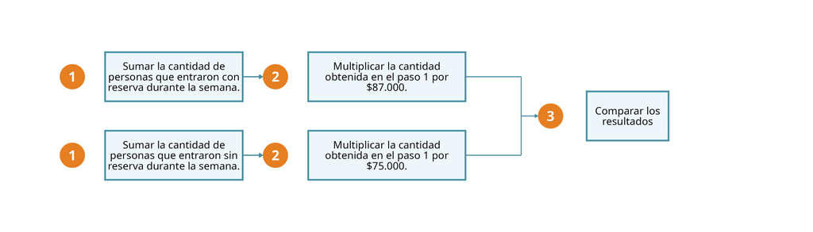

¿Cuál de las siguientes preguntas **NO** se puede resolver únicamente con la información obtenida mediante este proceso?

¿Cuál fue el total de dinero recogido por ambos casos durante la semana?¿En cuál de los dos casos se recogió más dinero durante la semana?¿Cuál fue la ganancia total de la Catedral de Sal durante la semana?¿En cuál día de la semana se recogió más dinero?

Para resolver este problema, debemos analizar qué información proporciona el proceso descrito:

**Información que SÍ se puede obtener del proceso:**

1. **Recaudación por tipo de entrada**: El proceso calcula cuánto dinero se recogió de personas con reserva (cantidad × 87.000 pesos) y sin reserva (cantidad × 75.000 pesos).
2. **Comparación entre casos**: El paso 3 permite comparar los resultados, determinando cuál tipo de entrada generó más ingresos.
3. **Total recaudado**: Sumando ambos resultados se obtiene el total de dinero recogido.

**Información que NO se puede obtener:**

- **Ganancia total**: La ganancia requiere conocer los costos operativos de la Catedral de Sal (personal, mantenimiento, servicios, etc.), información que no está incluida en el proceso.
- **Día específico**: El proceso trabaja con totales de la semana, no con datos diarios.

El Parque del Café en Montenegro, Quindío es uno de los sitios turísticos más representativos de Colombia. En la tabla se relaciona la cantidad de personas que ingresó cada día durante una semana, según el tipo de entrada que pagó.

Se pagan 90.000 pesos de entrada y 15.000 más si se realiza reserva.

Cantidad de personas que ingresaron

| Tipo de entrada | Lunes | Martes | Miércoles | Jueves | Viernes | Sábado | Domingo |
| --- | --- | --- | --- | --- | --- | --- | --- |
| Sin reserva | 400 | 400 | 400 | 700 | 400 | 300 | 600 |
| Con reserva | 600 | 700 | 200 | 500 | 400 | 400 | 600 |

El administrador diseñó el siguiente proceso para analizar la recaudación:

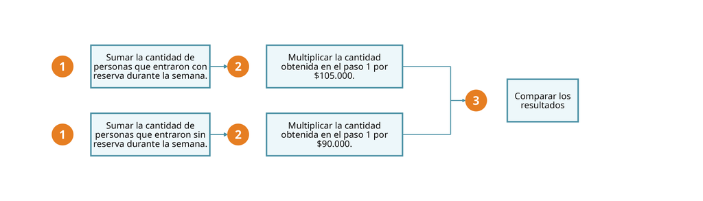

¿Cuál de las siguientes preguntas **NO** se puede resolver únicamente con la información obtenida mediante este proceso?

¿En cuál día de la semana se recogió más dinero?¿Cuál fue la ganancia total del Parque del Café durante la semana?¿Cuál fue el total de dinero recogido por ambos casos durante la semana?¿En cuál de los dos casos se recogió más dinero durante la semana?

Para resolver este problema, debemos analizar qué información proporciona el proceso descrito:

**Información que SÍ se puede obtener del proceso:**

1. **Recaudación por tipo de entrada**: El proceso calcula cuánto dinero se recogió de personas con reserva (cantidad × 105.000 pesos) y sin reserva (cantidad × 90.000 pesos).
2. **Comparación entre casos**: El paso 3 permite comparar los resultados, determinando cuál tipo de entrada generó más ingresos.
3. **Total recaudado**: Sumando ambos resultados se obtiene el total de dinero recogido.

**Información que NO se puede obtener:**

- **Ganancia total**: La ganancia requiere conocer los costos operativos del Parque del Café (personal, mantenimiento, servicios, etc.), información que no está incluida en el proceso.
- **Día específico**: El proceso trabaja con totales de la semana, no con datos diarios.

La Piedra del Peñol en Guatapé, Antioquia es uno de los sitios turísticos más representativos de Colombia. En la tabla se relaciona la cantidad de personas que ingresó cada día durante una semana, según el tipo de entrada que pagó.

Se pagan 32.000 pesos de entrada y 5.000 más si se realiza reserva.

Cantidad de personas que ingresaron

| Tipo de entrada | Lunes | Martes | Miércoles | Jueves | Viernes | Sábado | Domingo |
| --- | --- | --- | --- | --- | --- | --- | --- |
| Sin reserva | 300 | 300 | 600 | 700 | 300 | 300 | 500 |
| Con reserva | 600 | 800 | 200 | 600 | 400 | 500 | 700 |

El administrador diseñó el siguiente proceso para analizar la recaudación:

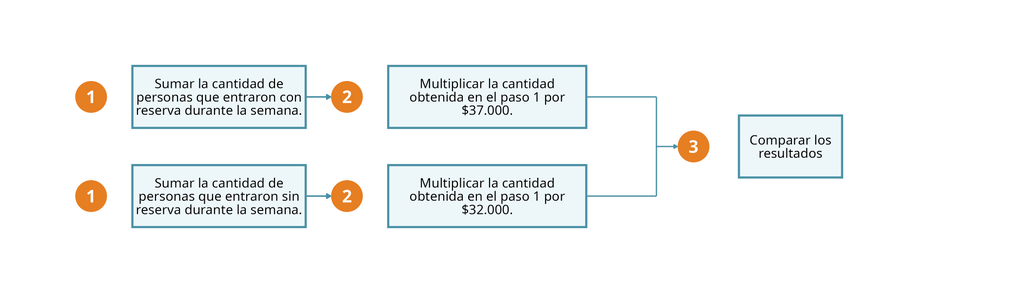

¿Cuál de las siguientes preguntas **NO** se puede resolver únicamente con la información obtenida mediante este proceso?

¿En cuál día de la semana se recogió más dinero?¿Cuál fue la ganancia total de la Piedra del Peñol durante la semana?¿En cuál de los dos casos se recogió más dinero durante la semana?¿Cuál fue el total de dinero recogido por ambos casos durante la semana?

Para resolver este problema, debemos analizar qué información proporciona el proceso descrito:

**Información que SÍ se puede obtener del proceso:**

1. **Recaudación por tipo de entrada**: El proceso calcula cuánto dinero se recogió de personas con reserva (cantidad × 37.000 pesos) y sin reserva (cantidad × 32.000 pesos).
2. **Comparación entre casos**: El paso 3 permite comparar los resultados, determinando cuál tipo de entrada generó más ingresos.
3. **Total recaudado**: Sumando ambos resultados se obtiene el total de dinero recogido.

**Información que NO se puede obtener:**

- **Ganancia total**: La ganancia requiere conocer los costos operativos de la Piedra del Peñol (personal, mantenimiento, servicios, etc.), información que no está incluida en el proceso.
- **Día específico**: El proceso trabaja con totales de la semana, no con datos diarios.

El Museo del Oro en Bogotá es uno de los sitios turísticos más representativos de Colombia. En la tabla se relaciona la cantidad de personas que ingresó cada día durante una semana, según el tipo de entrada que pagó.

Se pagan 4.000 pesos de entrada y 4.000 más si se realiza reserva.

Cantidad de personas que ingresaron

| Tipo de entrada | Lunes | Martes | Miércoles | Jueves | Viernes | Sábado | Domingo |
| --- | --- | --- | --- | --- | --- | --- | --- |
| Sin reserva | 300 | 300 | 500 | 500 | 400 | 300 | 800 |
| Con reserva | 600 | 600 | 200 | 500 | 400 | 400 | 600 |

El administrador diseñó el siguiente proceso para analizar la recaudación:

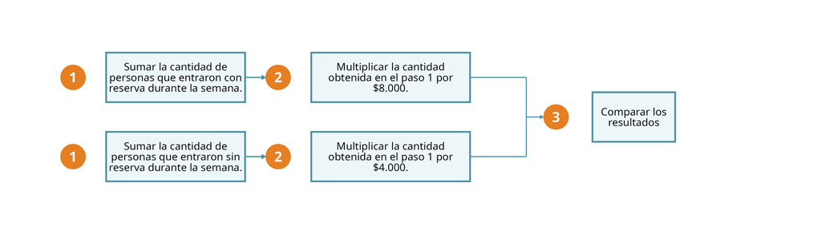

¿Cuál de las siguientes preguntas **NO** se puede resolver únicamente con la información obtenida mediante este proceso?

¿Cuál fue la ganancia total del Museo del Oro durante la semana?¿En cuál de los dos casos se recogió más dinero durante la semana?¿Cuál fue el total de dinero recogido por ambos casos durante la semana?¿En cuál día de la semana se recogió más dinero?

Para resolver este problema, debemos analizar qué información proporciona el proceso descrito:

**Información que SÍ se puede obtener del proceso:**

1. **Recaudación por tipo de entrada**: El proceso calcula cuánto dinero se recogió de personas con reserva (cantidad × 8.000 pesos) y sin reserva (cantidad × 4.000 pesos).
2. **Comparación entre casos**: El paso 3 permite comparar los resultados, determinando cuál tipo de entrada generó más ingresos.
3. **Total recaudado**: Sumando ambos resultados se obtiene el total de dinero recogido.

**Información que NO se puede obtener:**

- **Ganancia total**: La ganancia requiere conocer los costos operativos del Museo del Oro (personal, mantenimiento, servicios, etc.), información que no está incluida en el proceso.
- **Día específico**: El proceso trabaja con totales de la semana, no con datos diarios.

Las Islas Galápagos en Archipiélago de Colón es uno de los sitios turísticos más representativos de Ecuador. En la tabla se relaciona la cantidad de personas que ingresó cada día durante una semana, según el tipo de entrada que pagó.

Se pagan 200 dólares de entrada y 20 más si se realiza reserva.

Cantidad de personas que ingresaron

| Tipo de entrada | Lunes | Martes | Miércoles | Jueves | Viernes | Sábado | Domingo |
| --- | --- | --- | --- | --- | --- | --- | --- |
| Sin reserva | 400 | 300 | 400 | 600 | 300 | 300 | 700 |
| Con reserva | 800 | 800 | 200 | 500 | 600 | 400 | 500 |

El administrador diseñó el siguiente proceso para analizar la recaudación:

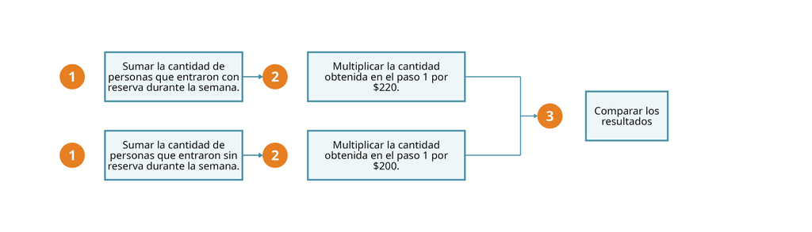

¿Cuál de las siguientes preguntas **NO** se puede resolver únicamente con la información obtenida mediante este proceso?

¿En cuál de los dos casos se recogió más dinero durante la semana?¿Cuál fue la ganancia total de la Islas Galápagos durante la semana?¿Cuál fue el total de dinero recogido por ambos casos durante la semana?¿En cuál día de la semana se recogió más dinero?

Para resolver este problema, debemos analizar qué información proporciona el proceso descrito:

**Información que SÍ se puede obtener del proceso:**

1. **Recaudación por tipo de entrada**: El proceso calcula cuánto dinero se recogió de personas con reserva (cantidad × 220 dólares) y sin reserva (cantidad × 200 dólares).
2. **Comparación entre casos**: El paso 3 permite comparar los resultados, determinando cuál tipo de entrada generó más ingresos.
3. **Total recaudado**: Sumando ambos resultados se obtiene el total de dinero recogido.

**Información que NO se puede obtener:**

- **Ganancia total**: La ganancia requiere conocer los costos operativos de la Islas Galápagos (personal, mantenimiento, servicios, etc.), información que no está incluida en el proceso.
- **Día específico**: El proceso trabaja con totales de la semana, no con datos diarios.

El centro histórico amurallado en Cartagena, Bolívar es uno de los sitios turísticos más representativos de Colombia. En la tabla se relaciona la cantidad de personas que ingresó cada día durante una semana, según el tipo de entrada que pagó.

Se pagan 28.000 pesos de entrada y 10.000 más si se realiza reserva.

Cantidad de personas que ingresaron

| Tipo de entrada | Lunes | Martes | Miércoles | Jueves | Viernes | Sábado | Domingo |
| --- | --- | --- | --- | --- | --- | --- | --- |
| Sin reserva | 300 | 400 | 500 | 600 | 400 | 300 | 700 |
| Con reserva | 700 | 800 | 300 | 600 | 500 | 500 | 600 |

El administrador diseñó el siguiente proceso para analizar la recaudación:

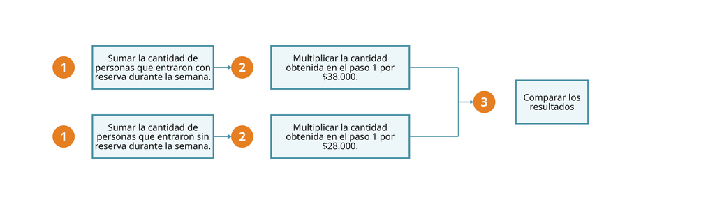

¿Cuál de las siguientes preguntas **NO** se puede resolver únicamente con la información obtenida mediante este proceso?

¿En cuál día de la semana se recogió más dinero?¿Cuál fue el total de dinero recogido por ambos casos durante la semana?¿En cuál de los dos casos se recogió más dinero durante la semana?¿Cuál fue la ganancia total del centro histórico amurallado durante la semana?

Para resolver este problema, debemos analizar qué información proporciona el proceso descrito:

**Información que SÍ se puede obtener del proceso:**

1. **Recaudación por tipo de entrada**: El proceso calcula cuánto dinero se recogió de personas con reserva (cantidad × 38.000 pesos) y sin reserva (cantidad × 28.000 pesos).
2. **Comparación entre casos**: El paso 3 permite comparar los resultados, determinando cuál tipo de entrada generó más ingresos.
3. **Total recaudado**: Sumando ambos resultados se obtiene el total de dinero recogido.

**Información que NO se puede obtener:**

- **Ganancia total**: La ganancia requiere conocer los costos operativos del centro histórico amurallado (personal, mantenimiento, servicios, etc.), información que no está incluida en el proceso.
- **Día específico**: El proceso trabaja con totales de la semana, no con datos diarios.